# Regresiones lineales, predictores categóricos y representación gráfica

2021-08-13

# 0. Objetivo de la práctica

El objetivo del práctico, es avanzar en la etapa de análisis de los datos a través del uso de **regresiones lineales**, para esto usaremos datos previamente procesados de la base de datos a utilizar. Recordemos que estamos en el proceso que nos encontramos del curso y con ello el flujo a utilizar.

[figure not shown]

Entonces, en esta práctica aprenderemos trabajar las **regresiones lineales**, también trabajaremos los **predictores categóricos**, luego veremos las diferencias de la estimación simple con **pesos muestrales**, para continuar con la **extracción de objetos** y finalmente veremos como **representarlos mediante gráficos y tablas**.

# 1. Recursos del práctico

En este práctico utilizamos los **datos procesados** de la [**Encuesta Suplementaria de Ingresos (ESI) 2020**](https://www.ine.cl/estadisticas/sociales/ingresos-y-gastos/encuesta-suplementaria-de-ingresos).Recuerden **siempre** consultar el [**libro códigos**](https://www.ine.cl/docs/default-source/encuesta-suplementaria-de-ingresos/bbdd/manual-y-gu%C3%ADa-de-variables/2020/personas-esi-2020.pdf?sfvrsn=f196cb4e_4) antes de trabajar datos.

# 2. Paquetes a utilizar

Para este práctico utilizaremos `srvyr` y `survey`, para estimar los modelos con peso muestral, `sjPlot` para la creación de tablas, `tidyverse` de este universo de paquetes utilizaremos `dplyr` (para la manipulación de datos) y `magrittr` (para utilizar el operador pipe). Recuerden que pueden ver más de las funciones de cada paquetes en la sección de recursos (*Cheatsheets*)

```r
pacman::p_load(sjPlot,
               tidyverse,
               srvyr,
               survey,
               magrittr)
```

# 3. Importar datos

Una vez cargado los paquetes a utilizar, debemos cargar los datos procesados.

```r
datos <- readRDS("output/data/datos_proc.rds")
```

## Explorar datos

Es relevante explorar los datos que utilizaremos, cómo están previamente procesados ¡no sabemos con que variables estamos trabajando!

```r
names(datos)
```

```
## [1] "ing_t_t"      "edad"         "sexo"         "est_conyugal" "ciuo08"
## [6] "fact_cal_esi"
```

```r
head(datos)
```

```
## # A tibble: 6 x 6
##   ing_t_t  edad       sexo est_conyugal                      ciuo08 fact_cal_esi
##     <dbl> <dbl>  <dbl+lbl> <chr>                          <dbl+lbl>        <dbl>
## 1 320421.    29 2 [Mujer]  Con pareja    5 [Trabajadores de los se~        346.
## 2 750000     30 2 [Mujer]  Sin pareja    2 [Profesionales, científ~       1056.
## 3 900000     43 2 [Mujer]  Sin pareja    2 [Profesionales, científ~         41.6
## 4      0     15 2 [Mujer]  Sin pareja   NA                                 265.
## 5      0     11 1 [Hombre] <NA>         NA                                 282.
## 6      0     62 2 [Mujer]  Sin pareja   NA                                 165.
```

Ahora sabemos que trabajaremos con seis variables: `"ing_t_t"`, `"est_conyugal"`, `"ciuo08"`, `"sexo"`, `"edad"` y `"fact_cal_esi"`,. Ahora inclusive podemos explorar nuestros datos con `sjPlot::view_df()`

```r
sjPlot::view_df(datos,
                encoding = "UTF-8")
```

Data frame: datos

| ID | Name | Label | Values | Value Labels |
| --- | --- | --- | --- | --- |
| 1 | ing_t_t | Total ingresos del trabajo | *range: 0.0-18045761.6* |  |
| 2 | edad | Edad de la persona | *range: 0-106* |  |
| 3 | sexo | Sexo | 1 2 | Hombre Mujer |
| 4 | est_conyugal |  |  | <output omitted> |
| 5 | ciuo08 | b1. Grupo ocupacional según CIUO 08 - 1 dígito | 1 2 3 4 5 6 7 8 9 10 999 | Directores, gerentes y administradores Profesionales, científicos e intelectuales Técnicos y profesionales de nivel medio Personal de apoyo administrativo Trabajadores de los servicios y vendedores … |
| 6 | fact_cal_esi | Factor de expansión ESI con nueva calibración, proyecciones de población | *range: 2.8-7070.1* |  |

Perfecto, podemos ver las variables que tenemos y sus categorías de respuesta pasaremos a la **regresión**

# 5. Modelo de regresión

## 5.1 Formula

Previo a eso recordemos que la fórmula de la regresión lineal simple es:

$$\begin{equation}
\widehat{Y}=b_{0} +b_{1}X
\end{equation}$$

Mientras que en la regresión lineal múltiple es:

$$\begin{equation}
\widehat{Y}=b_{0} +b_{1}X +b_{2}X +b_{x}X
\end{equation}$$

Donde

- $\widehat{Y}$ es el valor estimado/predicho de $Y$
- $b_{0}$ es el **intercepto** de la recta (el valor de Y cuando X es 0)
- $b_{1}$ y $b_{2}$ son los **coeficiente de regresión**, que nos dice cuánto aumenta Y por cada punto que aumenta X (pendiente)

Les mostramos esto porque de la misma forma se diferencian ambos procedimientos en R

Para la regresión lineal simple se utiliza la siguiente estructura:

```
objeto <- lm(dependiente ~ independiente, data=datos)
```

Mientras que para la regresión lineal múltiple, sólo se añaden más variables

```
objeto <- lm(dependiente ~ independiente1 + independiente 2 + independientex, data=datos)
```

## 5.2 Modelo

En este práctico no sólo aprenderemos a utilizar regresiones en R, sino que también a utilizalas con pesos muestrales. Pero, ¿cuál es la diferencia? ¡Ahora lo veremos!

### Modelo nulo sin pesos muestrales

Para ello crearemos en un objeto nuestro modelo nulo

```r
modelo0_sin <- lm(ing_t_t ~ 1,
              data = datos)
```

y lo visualizaremos con

```r
summary(modelo0_sin)
```

```
##
## Call:
## lm(formula = ing_t_t ~ 1, data = datos)
##
## Residuals:
##      Min       1Q   Median       3Q      Max
##  -206355  -206355  -206355    94039 17839407
##
## Coefficients:
##             Estimate Std. Error t value Pr(>|t|)
## (Intercept)   206355       1795     115   <2e-16 ***
## ---
## Signif. codes:  0 '***' 0.001 '**' 0.01 '*' 0.05 '.' 0.1 ' ' 1
##
## Residual standard error: 481300 on 71934 degrees of freedom
```

### Modelo nulo con pesos muestrales

Luego crearemos el modelo con peso muestral, para esto debemos añadir un nuevo argumento `weights`, donde se especifica el factor de expansión

```r
modelo0 <- lm(ing_t_t ~ 1,
              data = datos, weights = fact_cal_esi)
```

Ahora veremos los resultados con

```r
summary(modelo0)
```

```
##
## Call:
## lm(formula = ing_t_t ~ 1, data = datos, weights = fact_cal_esi)
##
## Weighted Residuals:
##       Min        1Q    Median        3Q       Max
## -21542431  -3770518  -2542853    488353 328574529
##
## Coefficients:
##             Estimate Std. Error t value Pr(>|t|)
## (Intercept)   256201       2090   122.6   <2e-16 ***
## ---
## Signif. codes:  0 '***' 0.001 '**' 0.01 '*' 0.05 '.' 0.1 ' ' 1
##
## Residual standard error: 9240000 on 71934 degrees of freedom
```

Entonces ¿qué diferencias hay?

```r
summary(modelo0);summary(modelo0_sin)
```

```
##
## Call:
## lm(formula = ing_t_t ~ 1, data = datos, weights = fact_cal_esi)
##
## Weighted Residuals:
##       Min        1Q    Median        3Q       Max
## -21542431  -3770518  -2542853    488353 328574529
##
## Coefficients:
##             Estimate Std. Error t value Pr(>|t|)
## (Intercept)   256201       2090   122.6   <2e-16 ***
## ---
## Signif. codes:  0 '***' 0.001 '**' 0.01 '*' 0.05 '.' 0.1 ' ' 1
##
## Residual standard error: 9240000 on 71934 degrees of freedom
```

```
##
## Call:
## lm(formula = ing_t_t ~ 1, data = datos)
##
## Residuals:
##      Min       1Q   Median       3Q      Max
##  -206355  -206355  -206355    94039 17839407
##
## Coefficients:
##             Estimate Std. Error t value Pr(>|t|)
## (Intercept)   206355       1795     115   <2e-16 ***
## ---
## Signif. codes:  0 '***' 0.001 '**' 0.01 '*' 0.05 '.' 0.1 ' ' 1
##
## Residual standard error: 481300 on 71934 degrees of freedom
```

Hay diferencias en el intercepto y en los errores estándar, ya que uno asume pesos de precisión y otro asume pesos muestrales.

Por ello es muy importante incorporar el peso muestral en el análisis, sino los estimadores puntuales no serán válidos y menos la inferencia que se realiza posteriormente, debido a la sobrestimación de la precisión de los estimadores.

## 5.3 Regresión lineal simple

Ahora estimaremos modelos simples

El primero sera entre ingresos y edad (`ing_t_t`, `edad`)

```r
modelo1 <- lm(ing_t_t ~ edad,
              data = datos, weights = fact_cal_esi)
```

```r
summary(modelo1)
```

```
##
## Call:
## lm(formula = ing_t_t ~ edad, data = datos, weights = fact_cal_esi)
##
## Weighted Residuals:
##       Min        1Q    Median        3Q       Max
## -21658308  -3745508  -2285119     35317 329034133
##
## Coefficients:
##              Estimate Std. Error t value Pr(>|t|)
## (Intercept) 127658.05    4042.33   31.58   <2e-16 ***
## edad          3511.38      94.84   37.03   <2e-16 ***
## ---
## Signif. codes:  0 '***' 0.001 '**' 0.01 '*' 0.05 '.' 0.1 ' ' 1
##
## Residual standard error: 9153000 on 71933 degrees of freedom
## Multiple R-squared:  0.0187, Adjusted R-squared:  0.01869
## F-statistic:  1371 on 1 and 71933 DF,  p-value: < 2.2e-16
```

También podemos ver la relación entre ingresos y sexo (`ing_t_t`, `sexo`)

```r
modelo2_sin <- lm(ing_t_t ~ sexo,
              data = datos, weights = fact_cal_esi)
```

```r
summary(modelo2_sin)
```

```
##
## Call:
## lm(formula = ing_t_t ~ sexo, data = datos, weights = fact_cal_esi)
##
## Weighted Residuals:
##       Min        1Q    Median        3Q       Max
## -27280367  -3615240  -2145275    120699 325618868
##
## Coefficients:
##             Estimate Std. Error t value Pr(>|t|)
## (Intercept)   498448       6568   75.89   <2e-16 ***
## sexo         -160784       4138  -38.86   <2e-16 ***
## ---
## Signif. codes:  0 '***' 0.001 '**' 0.01 '*' 0.05 '.' 0.1 ' ' 1
##
## Residual standard error: 9145000 on 71933 degrees of freedom
## Multiple R-squared:  0.02056,    Adjusted R-squared:  0.02055
## F-statistic:  1510 on 1 and 71933 DF,  p-value: < 2.2e-16
```

¡Pero espera! ¡`sexo` no es una variable continua!

### Predictores categóricos

Previo a esto hay que recordar que `sexo` no es un predictor continuo, y también debemos recordárselo a R. **Este es un proceso que debe realizarse en el código de preparación, pero para ver como procesa R los predictores categóricos en una regresión lo haremos acá**

Para ello utilizamos `forcats` un paquete del universo `tidyverse` con la función `as_factor`

```r
datos$sexo <-  forcats::as_factor(datos$sexo) #Recuerden que esto debería ir en el código de preparación
```

Listo ahora veremos el modelo

```r
modelo2 <- lm(ing_t_t ~ sexo,
              data = datos, weights = fact_cal_esi)
```

```r
summary(modelo2)
```

```
##
## Call:
## lm(formula = ing_t_t ~ sexo, data = datos, weights = fact_cal_esi)
##
## Weighted Residuals:
##       Min        1Q    Median        3Q       Max
## -27280367  -3615240  -2145275    120699 325618868
##
## Coefficients:
##             Estimate Std. Error t value Pr(>|t|)
## (Intercept)   337664       2945  114.65   <2e-16 ***
## sexoMujer    -160784       4138  -38.86   <2e-16 ***
## ---
## Signif. codes:  0 '***' 0.001 '**' 0.01 '*' 0.05 '.' 0.1 ' ' 1
##
## Residual standard error: 9145000 on 71933 degrees of freedom
## Multiple R-squared:  0.02056,    Adjusted R-squared:  0.02055
## F-statistic:  1510 on 1 and 71933 DF,  p-value: < 2.2e-16
```

Como pueden ver ahora especifica qué categoría de respuesta utiliza para la comparación, esto en la variable sexo quizá puede ser intuitivo, pero ¿qué pasaría con las que tienen otras categorías de respuesta?

intentémoslo con `ciuo08` y `est_conyugal`

```r
datos$ciuo08 <-  forcats::as_factor(datos$ciuo08)
datos$est_conyugal <-  forcats::as_factor(datos$est_conyugal)
# recuerden que es para el ejemplo, esto debía hacerse en el procesamiento
```

Modelo para `ciuo08`

```r
modelo3 <- lm(ing_t_t ~ ciuo08,
              data = datos, weights = fact_cal_esi)
```

```r
summary(modelo3)
```

```
##
## Call:
## lm(formula = ing_t_t ~ ciuo08, data = datos, weights = fact_cal_esi)
##
## Weighted Residuals:
##       Min        1Q    Median        3Q       Max
## -81184669  -3408145   -828630   1334160 263027210
##
## Coefficients:
##                                                                                     Estimate
## (Intercept)                                                                          2062790
## ciuo08Profesionales, científicos e intelectuales                                     -925708
## ciuo08Técnicos y profesionales de nivel medio                                       -1327327
## ciuo08Personal de apoyo administrativo                                              -1551221
## ciuo08Trabajadores de los servicios y vendedores de comercios y mercados            -1687053
## ciuo08Agricultores y trabajadores calificados agropecuarios, forestales y pesqueros -1717604
## ciuo08Artesanos y operarios de oficios                                              -1672564
## ciuo08Operadores de instalaciones, maquinas y ensambladores                         -1550495
## ciuo08Ocupaciones elementales                                                       -1782209
## ciuo08Otros no identificados                                                        -1019599
## ciuo08Sin clasificación                                                             -1737325
##                                                                                     Std. Error
## (Intercept)                                                                              19190
## ciuo08Profesionales, científicos e intelectuales                                         21334
## ciuo08Técnicos y profesionales de nivel medio                                            21921
## ciuo08Personal de apoyo administrativo                                                   24706
## ciuo08Trabajadores de los servicios y vendedores de comercios y mercados                 20888
## ciuo08Agricultores y trabajadores calificados agropecuarios, forestales y pesqueros      30756
## ciuo08Artesanos y operarios de oficios                                                   21957
## ciuo08Operadores de instalaciones, maquinas y ensambladores                              23380
## ciuo08Ocupaciones elementales                                                            21067
## ciuo08Otros no identificados                                                             58328
## ciuo08Sin clasificación                                                                 118089
##                                                                                     t value
## (Intercept)                                                                          107.49
## ciuo08Profesionales, científicos e intelectuales                                     -43.39
## ciuo08Técnicos y profesionales de nivel medio                                        -60.55
## ciuo08Personal de apoyo administrativo                                               -62.79
## ciuo08Trabajadores de los servicios y vendedores de comercios y mercados             -80.77
## ciuo08Agricultores y trabajadores calificados agropecuarios, forestales y pesqueros  -55.85
```

[output cut: 21 more lines]

```
## ciuo08Personal de apoyo administrativo                                              ***
## ciuo08Trabajadores de los servicios y vendedores de comercios y mercados            ***
## ciuo08Agricultores y trabajadores calificados agropecuarios, forestales y pesqueros ***
## ciuo08Artesanos y operarios de oficios                                              ***
## ciuo08Operadores de instalaciones, maquinas y ensambladores                         ***
## ciuo08Ocupaciones elementales                                                       ***
## ciuo08Otros no identificados                                                        ***
## ciuo08Sin clasificación                                                             ***
## ---
## Signif. codes:  0 '***' 0.001 '**' 0.01 '*' 0.05 '.' 0.1 ' ' 1
##
## Residual standard error: 10600000 on 26814 degrees of freedom
##   (45110 observations deleted due to missingness)
## Multiple R-squared:  0.3095, Adjusted R-squared:  0.3092
## F-statistic:  1202 on 10 and 26814 DF,  p-value: < 2.2e-16
```

Modelo para `est_conyugal`

```r
modelo4 <- lm(ing_t_t ~ est_conyugal,
              data = datos, weights = fact_cal_esi)
```

```r
summary(modelo4)
```

```
##
## Call:
## lm(formula = ing_t_t ~ est_conyugal, data = datos, weights = fact_cal_esi)
##
## Weighted Residuals:
##       Min        1Q    Median        3Q       Max
## -34630072  -4193409  -2453049    492227 322927197
##
## Coefficients:
##                        Estimate Std. Error t value Pr(>|t|)
## (Intercept)              411851       3546  116.13   <2e-16 ***
## est_conyugalSin pareja  -185302       4956  -37.39   <2e-16 ***
## ---
## Signif. codes:  0 '***' 0.001 '**' 0.01 '*' 0.05 '.' 0.1 ' ' 1
##
## Residual standard error: 9845000 on 58830 degrees of freedom
##   (13103 observations deleted due to missingness)
## Multiple R-squared:  0.02321,    Adjusted R-squared:  0.0232
## F-statistic:  1398 on 1 and 58830 DF,  p-value: < 2.2e-16
```

## 5.3 Regresión múltiple

Ahora queremos incorporar las demás variables al modelo, para lo haremos de la siguiente manera ( con +)

```r
modelo5 <- lm(ing_t_t ~ edad + sexo + ciuo08 + est_conyugal,
              data = datos, weights = fact_cal_esi)
```

```r
summary(modelo5)
```

```
##
## Call:
## lm(formula = ing_t_t ~ edad + sexo + ciuo08 + est_conyugal, data = datos,
##     weights = fact_cal_esi)
##
## Weighted Residuals:
##       Min        1Q    Median        3Q       Max
## -77029860  -3327667   -903696   1562319 261766339
##
## Coefficients:
##                                                                                       Estimate
## (Intercept)                                                                          1977240.3
## edad                                                                                    3645.5
## sexoMujer                                                                            -179308.4
## ciuo08Profesionales, científicos e intelectuales                                     -838561.6
## ciuo08Técnicos y profesionales de nivel medio                                       -1245145.4
## ciuo08Personal de apoyo administrativo                                              -1467502.5
## ciuo08Trabajadores de los servicios y vendedores de comercios y mercados            -1600971.8
## ciuo08Agricultores y trabajadores calificados agropecuarios, forestales y pesqueros -1752079.3
## ciuo08Artesanos y operarios de oficios                                              -1675160.8
## ciuo08Operadores de instalaciones, maquinas y ensambladores                         -1578961.8
## ciuo08Ocupaciones elementales                                                       -1718318.8
## ciuo08Otros no identificados                                                        -1042107.7
## ciuo08Sin clasificación                                                             -1693602.6
## est_conyugalSin pareja                                                               -113981.1
##                                                                                     Std. Error
## (Intercept)                                                                            23485.6
## edad                                                                                     290.2
## sexoMujer                                                                               7968.4
## ciuo08Profesionales, científicos e intelectuales                                       21117.6
## ciuo08Técnicos y profesionales de nivel medio                                          21664.4
## ciuo08Personal de apoyo administrativo                                                 24391.5
## ciuo08Trabajadores de los servicios y vendedores de comercios y mercados               20672.5
## ciuo08Agricultores y trabajadores calificados agropecuarios, forestales y pesqueros    30256.0
## ciuo08Artesanos y operarios de oficios                                                 21582.2
## ciuo08Operadores de instalaciones, maquinas y ensambladores                            23049.0
## ciuo08Ocupaciones elementales                                                          20781.6
## ciuo08Otros no identificados                                                           57343.4
## ciuo08Sin clasificación                                                               115936.4
## est_conyugalSin pareja                                                                  7609.8
```

[output cut: 37 more lines]

```
## ciuo08Trabajadores de los servicios y vendedores de comercios y mercados            ***
## ciuo08Agricultores y trabajadores calificados agropecuarios, forestales y pesqueros ***
## ciuo08Artesanos y operarios de oficios                                              ***
## ciuo08Operadores de instalaciones, maquinas y ensambladores                         ***
## ciuo08Ocupaciones elementales                                                       ***
## ciuo08Otros no identificados                                                        ***
## ciuo08Sin clasificación                                                             ***
## est_conyugalSin pareja                                                              ***
## ---
## Signif. codes:  0 '***' 0.001 '**' 0.01 '*' 0.05 '.' 0.1 ' ' 1
##
## Residual standard error: 10400000 on 26807 degrees of freedom
##   (45114 observations deleted due to missingness)
## Multiple R-squared:  0.3351, Adjusted R-squared:  0.3348
## F-statistic:  1039 on 13 and 26807 DF,  p-value: < 2.2e-16
```

### Regresión con paquete [`stats`](https://www.rdocumentation.org/packages/stats/versions/3.6.2)

`stats` tiene su función para hacer diverso tipo de regresiones, esta es `glm`, la cual tiene una estructura similar a la anterior, sólo que esta se debe especificar es tipo de regresión que se necesita en el argumento [`family`](https://www.statmethods.net/advstats/glm.html). Así quedaría nuestro modelo:

```r
modelo5_glm <- glm(ing_t_t ~ edad + sexo + ciuo08 + est_conyugal,
               family = gaussian(link = "identity"),
               data = datos, weights = fact_cal_esi)
```

```r
summary(modelo5_glm)
```

```
##
## Call:
## glm(formula = ing_t_t ~ edad + sexo + ciuo08 + est_conyugal,
##     family = gaussian(link = "identity"), data = datos, weights = fact_cal_esi)
##
## Deviance Residuals:
##       Min         1Q     Median         3Q        Max
## -77029860   -3327667    -903696    1562319  261766339
##
## Coefficients:
##                                                                                       Estimate
## (Intercept)                                                                          1977240.3
## edad                                                                                    3645.5
## sexoMujer                                                                            -179308.4
## ciuo08Profesionales, científicos e intelectuales                                     -838561.6
## ciuo08Técnicos y profesionales de nivel medio                                       -1245145.4
## ciuo08Personal de apoyo administrativo                                              -1467502.5
## ciuo08Trabajadores de los servicios y vendedores de comercios y mercados            -1600971.8
## ciuo08Agricultores y trabajadores calificados agropecuarios, forestales y pesqueros -1752079.3
## ciuo08Artesanos y operarios de oficios                                              -1675160.8
## ciuo08Operadores de instalaciones, maquinas y ensambladores                         -1578961.8
## ciuo08Ocupaciones elementales                                                       -1718318.8
## ciuo08Otros no identificados                                                        -1042107.7
## ciuo08Sin clasificación                                                             -1693602.6
## est_conyugalSin pareja                                                               -113981.1
##                                                                                     Std. Error
## (Intercept)                                                                            23485.6
## edad                                                                                     290.2
## sexoMujer                                                                               7968.4
## ciuo08Profesionales, científicos e intelectuales                                       21117.6
## ciuo08Técnicos y profesionales de nivel medio                                          21664.4
## ciuo08Personal de apoyo administrativo                                                 24391.5
## ciuo08Trabajadores de los servicios y vendedores de comercios y mercados               20672.5
## ciuo08Agricultores y trabajadores calificados agropecuarios, forestales y pesqueros    30256.0
## ciuo08Artesanos y operarios de oficios                                                 21582.2
## ciuo08Operadores de instalaciones, maquinas y ensambladores                            23049.0
## ciuo08Ocupaciones elementales                                                          20781.6
## ciuo08Otros no identificados                                                           57343.4
## ciuo08Sin clasificación                                                               115936.4
## est_conyugalSin pareja                                                                  7609.8
```

[output cut: 41 more lines]

```
## ciuo08Ocupaciones elementales                                                       ***
## ciuo08Otros no identificados                                                        ***
## ciuo08Sin clasificación                                                             ***
## est_conyugalSin pareja                                                              ***
## ---
## Signif. codes:  0 '***' 0.001 '**' 0.01 '*' 0.05 '.' 0.1 ' ' 1
##
## (Dispersion parameter for gaussian family taken to be 1.08223e+14)
##
##     Null deviance: 4.3633e+18  on 26820  degrees of freedom
## Residual deviance: 2.9011e+18  on 26807  degrees of freedom
##   (45114 observations deleted due to missingness)
## AIC: 801135
##
## Number of Fisher Scoring iterations: 2
```

### Regresión con paquete `survey`

`survey` también tiene su función para regresiones, para ello primero crearemos un objeto encuesta

```r
esi_design <- as_survey_design(datos, ids = 1, weights = fact_cal_esi)
```

Luego usamos la función `svyglm` y en el argumento `design` dejamos el objeto creado y así generamos nuestro modelo:

```r
modelo5_survey <- svyglm(ing_t_t ~ edad + sexo + ciuo08 + est_conyugal,
                         family = gaussian(link = "identity"),
                         design = esi_design)
```

Ahora visualizamos

```r
summary(modelo5_survey)
```

```
##
## Call:
## svyglm(formula = ing_t_t ~ edad + sexo + ciuo08 + est_conyugal,
##     design = esi_design, family = gaussian(link = "identity"))
##
## Survey design:
## Called via srvyr
##
## Coefficients:
##                                                                                       Estimate
## (Intercept)                                                                          1977240.3
## edad                                                                                    3645.5
## sexoMujer                                                                            -179308.4
## ciuo08Profesionales, científicos e intelectuales                                     -838561.6
## ciuo08Técnicos y profesionales de nivel medio                                       -1245145.4
## ciuo08Personal de apoyo administrativo                                              -1467502.5
## ciuo08Trabajadores de los servicios y vendedores de comercios y mercados            -1600971.8
## ciuo08Agricultores y trabajadores calificados agropecuarios, forestales y pesqueros -1752079.3
## ciuo08Artesanos y operarios de oficios                                              -1675160.8
## ciuo08Operadores de instalaciones, maquinas y ensambladores                         -1578961.8
## ciuo08Ocupaciones elementales                                                       -1718318.8
## ciuo08Otros no identificados                                                        -1042107.7
## ciuo08Sin clasificación                                                             -1693602.6
## est_conyugalSin pareja                                                               -113981.1
##                                                                                     Std. Error
## (Intercept)                                                                            88363.0
## edad                                                                                     452.1
## sexoMujer                                                                              13546.1
## ciuo08Profesionales, científicos e intelectuales                                       86714.7
## ciuo08Técnicos y profesionales de nivel medio                                          85675.3
## ciuo08Personal de apoyo administrativo                                                 84472.8
## ciuo08Trabajadores de los servicios y vendedores de comercios y mercados               83698.5
## ciuo08Agricultores y trabajadores calificados agropecuarios, forestales y pesqueros    83437.6
## ciuo08Artesanos y operarios de oficios                                                 83301.6
## ciuo08Operadores de instalaciones, maquinas y ensambladores                            83666.1
## ciuo08Ocupaciones elementales                                                          83108.3
## ciuo08Otros no identificados                                                          103555.4
## ciuo08Sin clasificación                                                               118605.3
## est_conyugalSin pareja                                                                 11951.0
##                                                                                     t value
```

[output cut: 35 more lines]

```
## ciuo08Personal de apoyo administrativo                                              ***
## ciuo08Trabajadores de los servicios y vendedores de comercios y mercados            ***
## ciuo08Agricultores y trabajadores calificados agropecuarios, forestales y pesqueros ***
## ciuo08Artesanos y operarios de oficios                                              ***
## ciuo08Operadores de instalaciones, maquinas y ensambladores                         ***
## ciuo08Ocupaciones elementales                                                       ***
## ciuo08Otros no identificados                                                        ***
## ciuo08Sin clasificación                                                             ***
## est_conyugalSin pareja                                                              ***
## ---
## Signif. codes:  0 '***' 0.001 '**' 0.01 '*' 0.05 '.' 0.1 ' ' 1
##
## (Dispersion parameter for gaussian family taken to be 398202555644)
##
## Number of Fisher Scoring iterations: 2
```

# ————– de acá —————

### Transformaciones funcionales

Para modelos log-lineal

```r
modelo5_log <- lm(log(ing_t_t) ~ edad + sexo + ciuo08 + est_conyugal,
              data = datos, weights = fact_cal_esi)
```

Para modelos log-cuadratico

```r
modelo5_log_cuadratico <- lm(log(ing_t_t) ~ edad + (edad)^2 + sexo + ciuo08 + est_conyugal,
                  data = datos, weights = fact_cal_esi)
```

Para modelo log-interaccion

```r
modelo5_log_cuadratico <- lm(log(ing_t_t) ~ edad  + sexo + ciuo08 + est_conyugal +
                               sexo*est_conyugal,
                             data = datos, weights = fact_cal_esi)
```

¡Pueden hacer la transformación funcional que estimen conveniente!

Para la creación exploratoria

```r
modelo_general <- lm(ing_t_t ~ .,
                     data = datos, weights = datos$fact_cal_esi,
                     na.action= na.omit)
```

```r
step(modelo_general, keep = nobs)
```

```
## Start:  AIC=798136.4
## ing_t_t ~ edad + sexo + est_conyugal + ciuo08 + fact_cal_esi
##
##                Df  Sum of Sq        RSS    AIC
## <none>                       3.1591e+18 798136
## - fact_cal_esi  1 1.2178e+15 3.1603e+18 798144
## - edad          1 1.8704e+16 3.1778e+18 798279
## - est_conyugal  1 3.6069e+16 3.1952e+18 798413
## - sexo          1 9.4531e+16 3.2536e+18 798859
## - ciuo08        1 8.4114e+17 4.0003e+18 803934
```

```
##
## Call:
## lm(formula = ing_t_t ~ edad + sexo + est_conyugal + ciuo08 +
##     fact_cal_esi, data = datos, weights = datos$fact_cal_esi,
##     na.action = na.omit)
##
## Coefficients:
##  (Intercept)          edad          sexo  est_conyugal        ciuo08
##   1711743.26       4049.82    -236961.92    -143871.95    -131580.99
## fact_cal_esi
##        14.69
```

# ————– hasta acá —————

## 5.4 Información de los modelos

Para conocer la información de los modelos, hay múltiples funciones que podemos utilizar:

La primera función es `str`, la cual nos mostrará su estructura

```r
str(modelo5)
```

```
## List of 15
##  $ coefficients : Named num [1:14] 1977240 3645 -179308 -838562 -1245145 ...
##   ..- attr(*, "names")= chr [1:14] "(Intercept)" "edad" "sexoMujer" "ciuo08Profesionales, científicos e intelectuales" ...
##  $ residuals    : Named num [1:26821] 17742 -204754 -102145 15920 -253034 ...
##   ..- attr(*, "label")= chr "Total ingresos del trabajo"
##   ..- attr(*, "format.stata")= chr "%10.0g"
##   ..- attr(*, "names")= chr [1:26821] "1" "2" "3" "7" ...
##  $ fitted.values: Named num [1:26821] 302679 954754 1002145 235781 393816 ...
##   ..- attr(*, "label")= chr "Total ingresos del trabajo"
##   ..- attr(*, "format.stata")= chr "%10.0g"
##   ..- attr(*, "names")= chr [1:26821] "1" "2" "3" "7" ...
##  $ effects      : Named num [1:26821] -1.74e+09 1.33e+08 1.76e+08 6.89e+08 2.83e+08 ...
##   ..- attr(*, "label")= chr "Total ingresos del trabajo"
##   ..- attr(*, "format.stata")= chr "%10.0g"
##   ..- attr(*, "names")= chr [1:26821] "(Intercept)" "edad" "sexoMujer" "ciuo08Profesionales, científicos e intelectuales" ...
##  $ weights      : num [1:26821] 345.8 1056.5 41.6 730.4 270.1 ...
##  $ rank         : int 14
##  $ assign       : int [1:14] 0 1 2 3 3 3 3 3 3 3 ...
##  $ qr           :List of 5
##   ..$ qr   : num [1:26821, 1:14] -2.84e+03 1.15e-02 2.27e-03 9.52e-03 5.79e-03 ...
##   .. ..- attr(*, "assign")= int [1:14] 0 1 2 3 3 3 3 3 3 3 ...
##   .. ..- attr(*, "contrasts")=List of 3
##   .. .. ..$ sexo        : chr "contr.treatment"
##   .. .. ..$ ciuo08      : chr "contr.treatment"
##   .. .. ..$ est_conyugal: chr "contr.treatment"
##   .. ..- attr(*, "dimnames")=List of 2
##   .. .. ..$ : chr [1:26821] "1" "2" "3" "7" ...
##   .. .. ..$ : chr [1:14] "(Intercept)" "edad" "sexoMujer" "ciuo08Profesionales, científicos e intelectuales" ...
##   ..$ qraux: num [1:14] 1.01 1.01 1 1.01 1 ...
##   ..$ pivot: int [1:14] 1 2 3 4 5 6 7 8 9 10 ...
##   ..$ tol  : num 1e-07
##   ..$ rank : int 14
##   ..- attr(*, "class")= chr "qr"
##  $ df.residual  : int 26807
##  $ na.action    : 'omit' Named int [1:45114] 4 5 6 8 11 14 16 17 19 21 ...
##   ..- attr(*, "names")= chr [1:45114] "4" "5" "6" "8" ...
##  $ contrasts    :List of 3
##   ..$ sexo        : chr "contr.treatment"
##   ..$ ciuo08      : chr "contr.treatment"
##   ..$ est_conyugal: chr "contr.treatment"
```

[output cut: 36 more lines]

```
##   .. .. ..- attr(*, "factors")= int [1:5, 1:4] 0 1 0 0 0 0 0 1 0 0 ...
##   .. .. .. ..- attr(*, "dimnames")=List of 2
##   .. .. .. .. ..$ : chr [1:5] "ing_t_t" "edad" "sexo" "ciuo08" ...
##   .. .. .. .. ..$ : chr [1:4] "edad" "sexo" "ciuo08" "est_conyugal"
##   .. .. ..- attr(*, "term.labels")= chr [1:4] "edad" "sexo" "ciuo08" "est_conyugal"
##   .. .. ..- attr(*, "order")= int [1:4] 1 1 1 1
##   .. .. ..- attr(*, "intercept")= int 1
##   .. .. ..- attr(*, "response")= int 1
##   .. .. ..- attr(*, ".Environment")=<environment: R_GlobalEnv>
##   .. .. ..- attr(*, "predvars")= language list(ing_t_t, edad, sexo, ciuo08, est_conyugal)
##   .. .. ..- attr(*, "dataClasses")= Named chr [1:6] "numeric" "numeric" "factor" "factor" ...
##   .. .. .. ..- attr(*, "names")= chr [1:6] "ing_t_t" "edad" "sexo" "ciuo08" ...
##   ..- attr(*, "na.action")= 'omit' Named int [1:45114] 4 5 6 8 11 14 16 17 19 21 ...
##   .. ..- attr(*, "names")= chr [1:45114] "4" "5" "6" "8" ...
##  - attr(*, "class")= chr "lm"
```

Luego esta `summary`, la cual hemos estado utilizando a lo largo del práctico

```r
summary(modelo5)
```

```
##
## Call:
## lm(formula = ing_t_t ~ edad + sexo + ciuo08 + est_conyugal, data = datos,
##     weights = fact_cal_esi)
##
## Weighted Residuals:
##       Min        1Q    Median        3Q       Max
## -77029860  -3327667   -903696   1562319 261766339
##
## Coefficients:
##                                                                                       Estimate
## (Intercept)                                                                          1977240.3
## edad                                                                                    3645.5
## sexoMujer                                                                            -179308.4
## ciuo08Profesionales, científicos e intelectuales                                     -838561.6
## ciuo08Técnicos y profesionales de nivel medio                                       -1245145.4
## ciuo08Personal de apoyo administrativo                                              -1467502.5
## ciuo08Trabajadores de los servicios y vendedores de comercios y mercados            -1600971.8
## ciuo08Agricultores y trabajadores calificados agropecuarios, forestales y pesqueros -1752079.3
## ciuo08Artesanos y operarios de oficios                                              -1675160.8
## ciuo08Operadores de instalaciones, maquinas y ensambladores                         -1578961.8
## ciuo08Ocupaciones elementales                                                       -1718318.8
## ciuo08Otros no identificados                                                        -1042107.7
## ciuo08Sin clasificación                                                             -1693602.6
## est_conyugalSin pareja                                                               -113981.1
##                                                                                     Std. Error
## (Intercept)                                                                            23485.6
## edad                                                                                     290.2
## sexoMujer                                                                               7968.4
## ciuo08Profesionales, científicos e intelectuales                                       21117.6
## ciuo08Técnicos y profesionales de nivel medio                                          21664.4
## ciuo08Personal de apoyo administrativo                                                 24391.5
## ciuo08Trabajadores de los servicios y vendedores de comercios y mercados               20672.5
## ciuo08Agricultores y trabajadores calificados agropecuarios, forestales y pesqueros    30256.0
## ciuo08Artesanos y operarios de oficios                                                 21582.2
## ciuo08Operadores de instalaciones, maquinas y ensambladores                            23049.0
## ciuo08Ocupaciones elementales                                                          20781.6
## ciuo08Otros no identificados                                                           57343.4
## ciuo08Sin clasificación                                                               115936.4
## est_conyugalSin pareja                                                                  7609.8
```

[output cut: 37 more lines]

```
## ciuo08Trabajadores de los servicios y vendedores de comercios y mercados            ***
## ciuo08Agricultores y trabajadores calificados agropecuarios, forestales y pesqueros ***
## ciuo08Artesanos y operarios de oficios                                              ***
## ciuo08Operadores de instalaciones, maquinas y ensambladores                         ***
## ciuo08Ocupaciones elementales                                                       ***
## ciuo08Otros no identificados                                                        ***
## ciuo08Sin clasificación                                                             ***
## est_conyugalSin pareja                                                              ***
## ---
## Signif. codes:  0 '***' 0.001 '**' 0.01 '*' 0.05 '.' 0.1 ' ' 1
##
## Residual standard error: 10400000 on 26807 degrees of freedom
##   (45114 observations deleted due to missingness)
## Multiple R-squared:  0.3351, Adjusted R-squared:  0.3348
## F-statistic:  1039 on 13 and 26807 DF,  p-value: < 2.2e-16
```

¿Pero que pasa si queremos un elemento en particular del modelo?, como este es un objeto, se puede utilizar el símbolo `$` para extraer información de este

```r
modelo5$coefficients
```

```
##                                                                         (Intercept)
##                                                                         1977240.278
##                                                                                edad
##                                                                            3645.488
##                                                                           sexoMujer
##                                                                         -179308.422
##                                    ciuo08Profesionales, científicos e intelectuales
##                                                                         -838561.638
##                                       ciuo08Técnicos y profesionales de nivel medio
##                                                                        -1245145.411
##                                              ciuo08Personal de apoyo administrativo
##                                                                        -1467502.547
##            ciuo08Trabajadores de los servicios y vendedores de comercios y mercados
##                                                                        -1600971.794
## ciuo08Agricultores y trabajadores calificados agropecuarios, forestales y pesqueros
##                                                                        -1752079.303
##                                              ciuo08Artesanos y operarios de oficios
##                                                                        -1675160.786
##                         ciuo08Operadores de instalaciones, maquinas y ensambladores
##                                                                        -1578961.831
##                                                       ciuo08Ocupaciones elementales
##                                                                        -1718318.836
##                                                        ciuo08Otros no identificados
##                                                                        -1042107.683
##                                                             ciuo08Sin clasificación
##                                                                        -1693602.555
##                                                              est_conyugalSin pareja
##                                                                         -113981.138
```

```r
modelo5$coefficients[2]
```

```
##     edad
## 3645.488
```

```r
modelo5$coefficients["edad"]
```

```
##     edad
## 3645.488
```

¿Qué otros elementos puedo extraer?, para eso `str` nos dirá estructura y elementos que podremos utilizar

```r
str(summary(modelo5))
```

```
## List of 13
##  $ call         : language lm(formula = ing_t_t ~ edad + sexo + ciuo08 + est_conyugal, data = datos,      weights = fact_cal_esi)
##  $ terms        :Classes 'terms', 'formula'  language ing_t_t ~ edad + sexo + ciuo08 + est_conyugal
##   .. ..- attr(*, "variables")= language list(ing_t_t, edad, sexo, ciuo08, est_conyugal)
##   .. ..- attr(*, "factors")= int [1:5, 1:4] 0 1 0 0 0 0 0 1 0 0 ...
##   .. .. ..- attr(*, "dimnames")=List of 2
##   .. .. .. ..$ : chr [1:5] "ing_t_t" "edad" "sexo" "ciuo08" ...
##   .. .. .. ..$ : chr [1:4] "edad" "sexo" "ciuo08" "est_conyugal"
##   .. ..- attr(*, "term.labels")= chr [1:4] "edad" "sexo" "ciuo08" "est_conyugal"
##   .. ..- attr(*, "order")= int [1:4] 1 1 1 1
##   .. ..- attr(*, "intercept")= int 1
##   .. ..- attr(*, "response")= int 1
##   .. ..- attr(*, ".Environment")=<environment: R_GlobalEnv>
##   .. ..- attr(*, "predvars")= language list(ing_t_t, edad, sexo, ciuo08, est_conyugal)
##   .. ..- attr(*, "dataClasses")= Named chr [1:6] "numeric" "numeric" "factor" "factor" ...
##   .. .. ..- attr(*, "names")= chr [1:6] "ing_t_t" "edad" "sexo" "ciuo08" ...
##  $ weights      : num [1:26821] 345.8 1056.5 41.6 730.4 270.1 ...
##  $ residuals    : Named num [1:26821] 329915 -6655171 -658927 430264 -4158305 ...
##   ..- attr(*, "label")= chr "Total ingresos del trabajo"
##   ..- attr(*, "format.stata")= chr "%10.0g"
##   ..- attr(*, "names")= chr [1:26821] "1" "2" "3" "7" ...
##  $ coefficients : num [1:14, 1:4] 1977240 3645 -179308 -838562 -1245145 ...
##   ..- attr(*, "dimnames")=List of 2
##   .. ..$ : chr [1:14] "(Intercept)" "edad" "sexoMujer" "ciuo08Profesionales, científicos e intelectuales" ...
##   .. ..$ : chr [1:4] "Estimate" "Std. Error" "t value" "Pr(>|t|)"
##  $ aliased      : Named logi [1:14] FALSE FALSE FALSE FALSE FALSE FALSE ...
##   ..- attr(*, "names")= chr [1:14] "(Intercept)" "edad" "sexoMujer" "ciuo08Profesionales, científicos e intelectuales" ...
##  $ sigma        : num 10403029
##  $ df           : int [1:3] 14 26807 14
##  $ r.squared    : num 0.335
##  $ adj.r.squared: num 0.335
##  $ fstatistic   : Named num [1:3] 1039 13 26807
##   ..- attr(*, "names")= chr [1:3] "value" "numdf" "dendf"
##  $ cov.unscaled : num [1:14, 1:14] 5.10e-06 -3.68e-08 -1.59e-07 -3.41e-06 -3.38e-06 ...
##   ..- attr(*, "dimnames")=List of 2
##   .. ..$ : chr [1:14] "(Intercept)" "edad" "sexoMujer" "ciuo08Profesionales, científicos e intelectuales" ...
##   .. ..$ : chr [1:14] "(Intercept)" "edad" "sexoMujer" "ciuo08Profesionales, científicos e intelectuales" ...
##  $ na.action    : 'omit' Named int [1:45114] 4 5 6 8 11 14 16 17 19 21 ...
##   ..- attr(*, "names")= chr [1:45114] "4" "5" "6" "8" ...
##  - attr(*, "class")= chr "summary.lm"
```

```r
summary(modelo5)$fstatistic
```

```
##     value     numdf     dendf
##  1039.257    13.000 26807.000
```

```r
summary(modelo5)$r.squared
```

```
## [1] 0.3351
```

Para los valores predichos utilizaremos la función de `sjPlot::get_model_data`

```r
modelo5$fitted.values
```

```r
get_model_data(modelo5, type = c("pred"))
```

```
## $edad
## # Predicted values of Total ingresos del trabajo
##
## edad | Predicted | group_col |               95% CI
## ---------------------------------------------------
##   10 |  2.01e+06 |      edad | [1.97e+06, 2.06e+06]
##   20 |  2.05e+06 |      edad | [2.01e+06, 2.09e+06]
##   30 |  2.09e+06 |      edad | [2.05e+06, 2.13e+06]
##   40 |  2.12e+06 |      edad | [2.09e+06, 2.16e+06]
##   60 |  2.20e+06 |      edad | [2.16e+06, 2.23e+06]
##   70 |  2.23e+06 |      edad | [2.19e+06, 2.27e+06]
##   80 |  2.27e+06 |      edad | [2.23e+06, 2.31e+06]
##  100 |  2.34e+06 |      edad | [2.29e+06, 2.39e+06]
##
## Adjusted for:
## *         sexo =                                 Hombre
## *       ciuo08 = Directores, gerentes y administradores
## * est_conyugal =                             Con pareja
##
## $sexo
## # Predicted values of Total ingresos del trabajo
##
## sexo | Predicted | group_col |               95% CI
## ---------------------------------------------------
##    1 |  2.13e+06 |      sexo | [2.09e+06, 2.17e+06]
##    2 |  1.95e+06 |      sexo | [1.91e+06, 1.99e+06]
##
## Adjusted for:
## *         edad =                                  42.13
## *       ciuo08 = Directores, gerentes y administradores
## * est_conyugal =                             Con pareja
##
## $ciuo08
## # Predicted values of Total ingresos del trabajo
##
## ciuo08 | Predicted | group_col |               95% CI
## -----------------------------------------------------
##      1 |  2.13e+06 |    ciuo08 | [2.09e+06, 2.17e+06]
##      2 |  1.29e+06 |    ciuo08 | [1.27e+06, 1.31e+06]
##      4 |  6.63e+05 |    ciuo08 | [6.32e+05, 6.95e+05]
```

[output cut: 8 more lines]

```
## *         sexo =     Hombre
## * est_conyugal = Con pareja
##
## $est_conyugal
## # Predicted values of Total ingresos del trabajo
##
## est_conyugal | Predicted |    group_col |               95% CI
## --------------------------------------------------------------
##            1 |  2.13e+06 | est_conyugal | [2.09e+06, 2.17e+06]
##            2 |  2.02e+06 | est_conyugal | [1.98e+06, 2.06e+06]
##
## Adjusted for:
## *   edad =                                  42.13
## *   sexo =                                 Hombre
## * ciuo08 = Directores, gerentes y administradores
```

```r
get_model_data(modelo5, type = "pred", terms = "sexo")
```

```
## # Predicted values of Total ingresos del trabajo
##
## sexo | Predicted | group_col |               95% CI
## ---------------------------------------------------
##    1 |  2.13e+06 |         1 | [2.09e+06, 2.17e+06]
##    2 |  1.95e+06 |         1 | [1.91e+06, 1.99e+06]
##
## Adjusted for:
## *         edad =                                  42.13
## *       ciuo08 = Directores, gerentes y administradores
## * est_conyugal =                             Con pareja
```

con `broom`, podemos convertir objetos en dataframes, inclusive si lo dejamos a un objeto, podemos imprimirlo con `tab_df` de `sjPlot`

```r
print <- broom::augment(modelo5)
```

```r
tab_df(print, file = "output/data/modelo.doc")
```

Esto nos lleva al último punto del práctico, la visualización

# 6. Visualización

Si bien `summary` es un código muy útil para visualizar los modelos creados, el problema es que al observar el objeto creado, no es muy presentable para informes, por eso usaremos la función `tab_model` de `sjPlot`, que tiene la siguiente estructura:

```r
sjPlot::tab_model(objeto_creado,
                  show.ci= F/T,  # este argumento muestra los intervalos de confianza
                  encoding = "UTF-8",  # evita errores en caracteres
                  file = "output/figures/reg1_tab.doc") # guarda lo creado automáticamente
```

Para visualizar sólo un modelo puede hacerse de esta forma y en nuestros datos se vería así:

```r
sjPlot::tab_model(modelo0, show.ci=FALSE,  encoding = "UTF-8", file = "output/figures/regnc_tab.doc")
```

|  | Total ingresos del trabajo |  |
| --- | --- | --- |
| Predictors | Estimates | p |
| (Intercept) | 256201.13 | **<0.001** |
| Observations | 71935 |  |
| R<sup>2</sup> / R<sup>2</sup> adjusted | 0.000 / 0.000 |  |

Las ventajas de este código es que se puede especificar el `encoding`, y se puede exportar la tabla, que tiene mejor visualización que la que arroja la consola con `summary`

Pero además se pueden incluir más modelos creados en una sola tabla, para eso usaremos nuevamente la función `tab_model` de `sjPlot`

```r
sjPlot::tab_model(list(modelo0, modelo1, modelo2), # los modelos estimados
  show.ci=FALSE, # no mostrar intervalo de confianza (por defecto lo hace)
  p.style = "stars", # asteriscos de significación estadística
  dv.labels = c("Modelo 1", "Modelo 2", "Modelo 3"), # etiquetas de modelos o variables dep.
  string.pred = "Predictores", string.est = "β", # nombre predictores y símbolo beta en tabla
  encoding =  "UTF-8",
  file = "output/figures/reg_tab_all.doc")
```

Modelo 1

Modelo 2

Modelo 3

Predictores

ß

ß

ß

(Intercept)

256201.13 ***

127658.05 ***

337663.87 ***

Edad de la persona

3511.38 ***

Sexo: Mujer

-160784.29 ***

Observations

71935

71935

71935

R<sup>2</sup> / R<sup>2</sup> adjusted

0.000 / 0.000

0.019 / 0.019

0.021 / 0.021

- p<0.05 ** p<0.01 *** p<0.001

También se pueden especificar las etiquetas con `dv.labels` y cómo queremos que nos incorpore la significación estadística, con `p.style`

Para visualizar o graficar los coeficientes de regresión para poder observar el impacto de cada variable en el modelo utilizaremos la función `plot_model` de `sjPlot`, su estructura es la siguiente:

```r
sjPlot::plot_model(objeto_creado,
                   ci.lvl = "", #estima el nivel de confianza
                   title = "",  # es el título
                   show.p = T, # nos muestra los valores p
                   show.values =  T, # nos muestra los valores
                   vline.color = "") # color de la recta vertical
```

Esto visualizado con nuestro modelo se ve así:

[figure not shown]

```r
sjPlot::plot_model(modelo5_log,
                   show.p = T,
                   show.values =  T,
                   ci.lvl = c(0.95),
                   title = "Estimación de predictores",
                   vline.color = "purple")
```

### Efectos marginales

Para esto con el argumento `type`, podemos especificar los calores predichos para los **términos** específicos del modelo

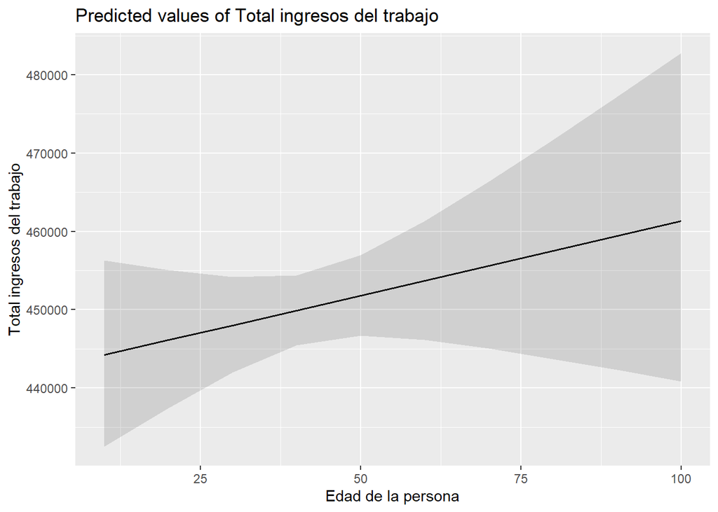

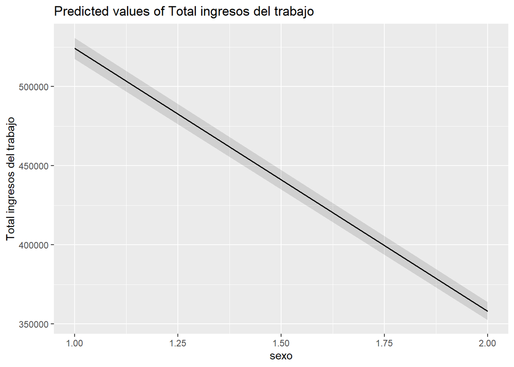

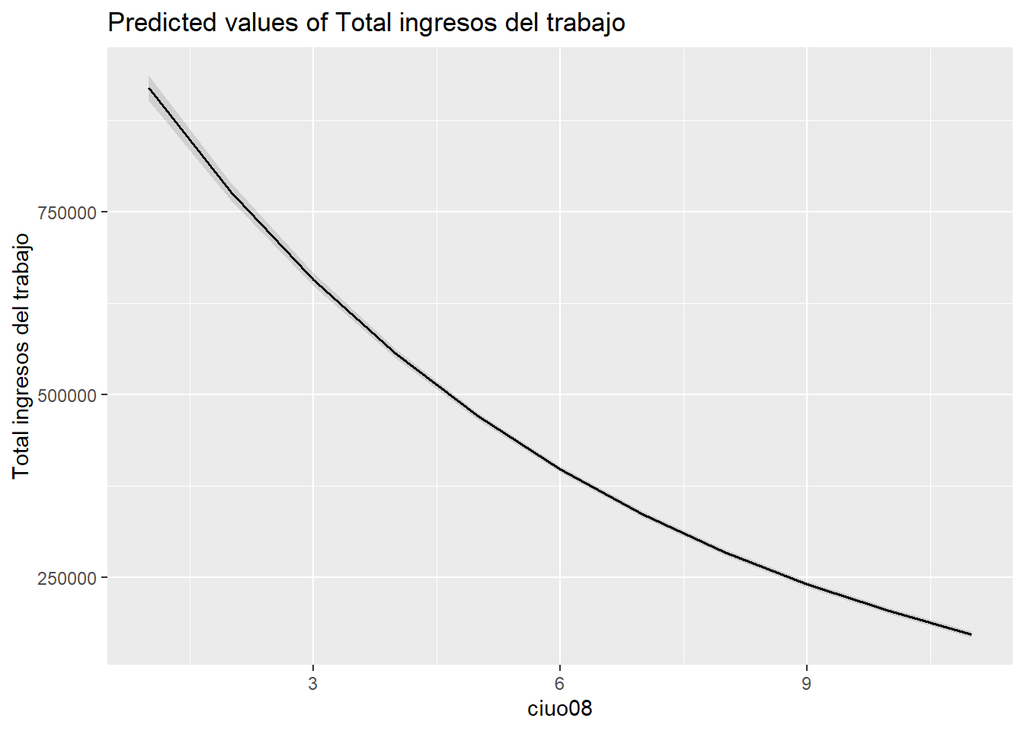

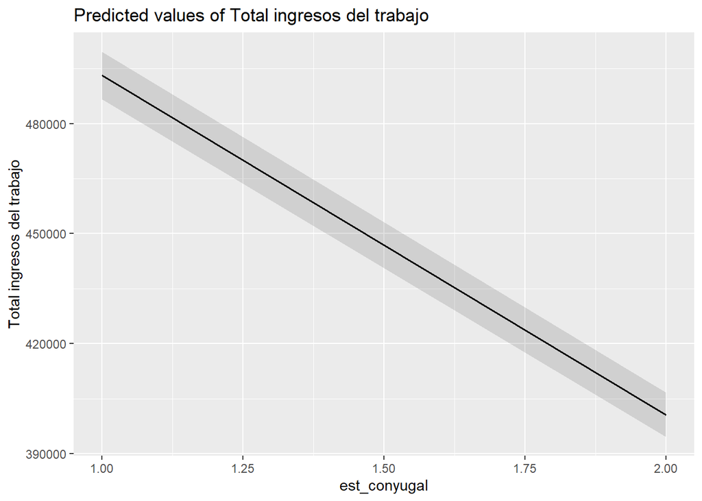

```r
plot_model(modelo5_log,
           type = "pred")
```

Y para especificar los términos se utiliza el argumento `terms`, lo que indica los términos a mostrar en los efector marginales

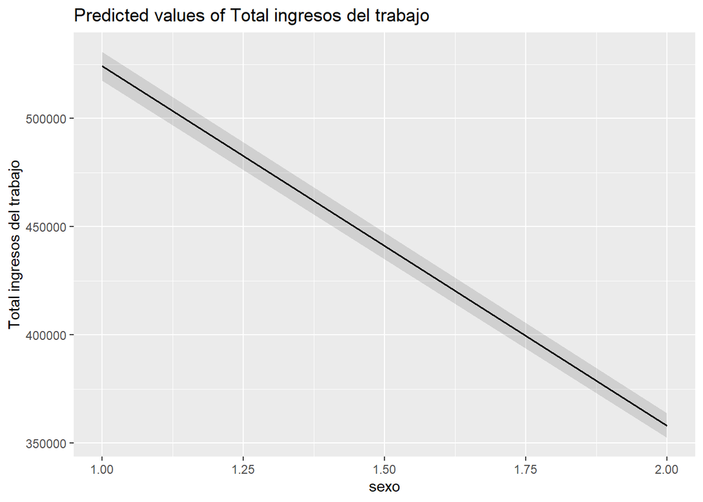

```r
plot_model(modelo5_log,
           type = "pred",
           terms = "sexo")
```

Debe mencionarse al menos uno y máximo tres

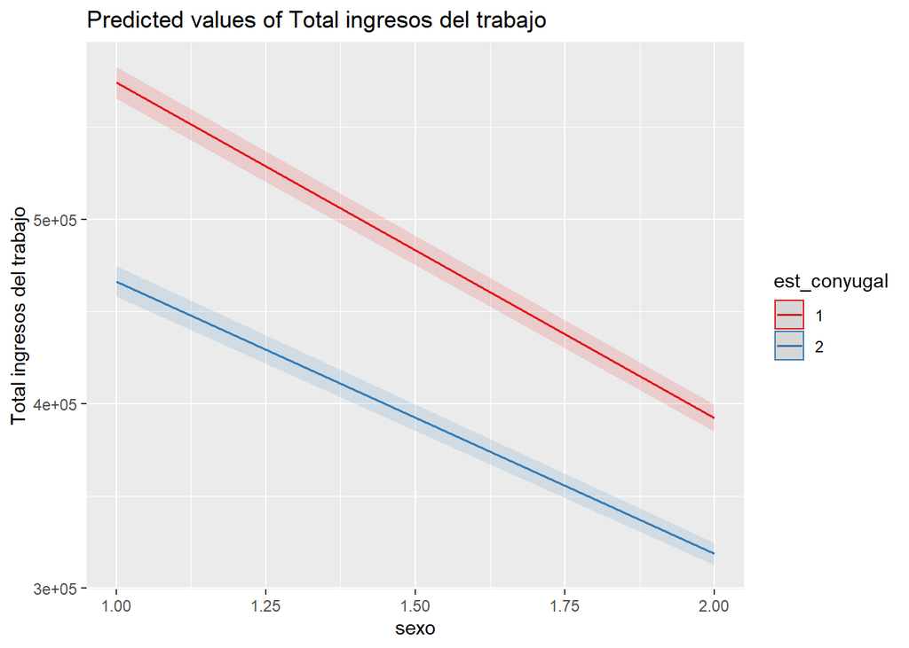

```r
plot_model(modelo5_log,
           type = "pred",
           terms = c("sexo", "est_conyugal"))
```

Terminamos por este práctico ¡Pero aún falta la regresión logística!, para eso nos vemos en la próxima clase

# 7. Resumen

En este práctico aprendimos a

- Crear y visualizar regresiones lineales
- Incorporar predictores categóricos
- Crear y visualizar regresiones múltiples

# 8. Recursos

- [sjPlot](https://strengejacke.github.io/sjPlot/)
- [tidyverse](https://www.tidyverse.org/packages/)
- [magrittr](https://magrittr.tidyverse.org/)

# 9. Reporte de progreso

¡Recuerda rellenar tu reporte de progreso. En tu correo electrónico está disponible el código mediante al cuál debes acceder para actualizar tu estado de avance del curso.